# Predictive Modelling

Maria Pais, Mónica Araújo

2023-11-07

# 1 Load Data

The data is already preprocessed in the DataPreparation step. The result is save in a RData file.

```r
# train dataset
load("Rdata/train/merge_data_train.Rdata")

# test dataset
load("Rdata/test/merge_data_test.Rdata")

load("Rdata/merge_data.Rdata")

load("Rdata/merge_data_kaggle.Rdata")
```

# 2 Predictive Modelling

## 2.1 Decision Trees

```r
selected_columns2 <- merge_data %>%
     select(age,status,district_id,have_card,`average salary`, money_in_account, gender_F)

selected_columns2$status <- as.integer(selected_columns2$status)
```

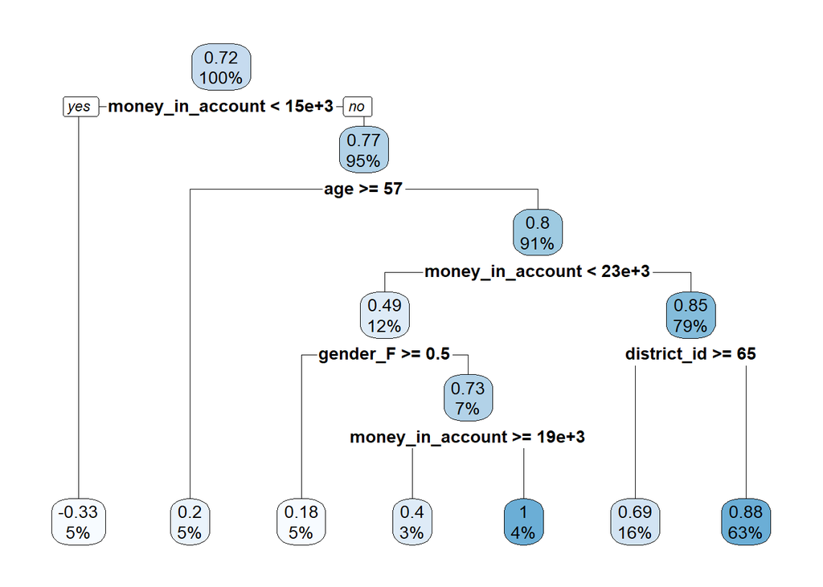

```r
model_rt <- decision_tree(mode = "regression", engine = "rpart")
rt_fit <- model_rt %>%
  fit(status ~ ., data = selected_columns2)

rt_fit %>%
  extract_fit_engine() %>%
    rpart.plot(roundint = FALSE)
```

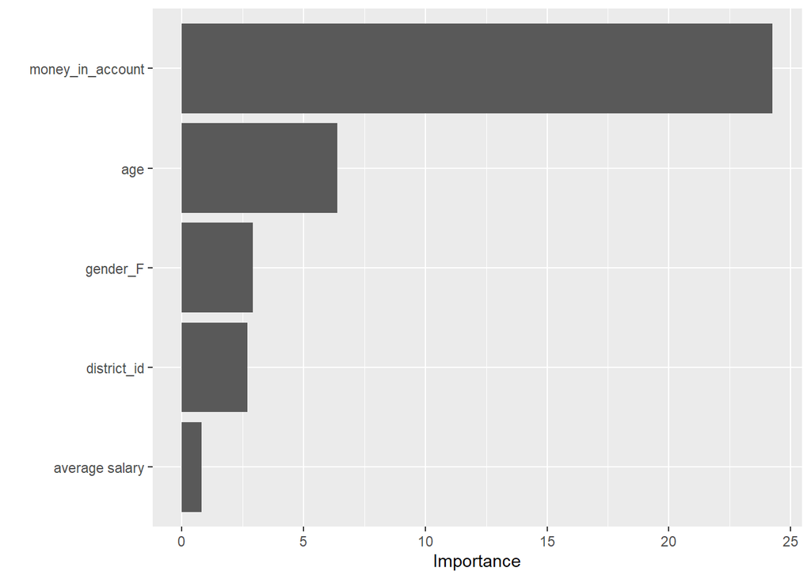

```r
vip(rt_fit)
```

## 2.2 Linear Regression

```r
merge_data_train$status <- as.numeric(as.character(merge_data_train$status))

# Create a linear regression model
linear_model <- lm(status ~ age + district_id + gender_F + money_in_account + `average salary`, data = merge_data_train)

# Print the summary of the model
summary(linear_model)
```

```
##
## Call:
## lm(formula = status ~ age + district_id + gender_F + money_in_account +
##     `average salary`, data = merge_data_train)
##
## Residuals:
##     Min      1Q  Median      3Q     Max
## -2.1228  0.1190  0.2671  0.3385  0.4368
##
## Coefficients:
##                    Estimate Std. Error t value Pr(>|t|)
## (Intercept)       0.7627712  0.0958909   7.955 5.81e-14 ***
## age              -0.0188916  0.0429277  -0.440  0.66025
## district_id      -0.0005803  0.0019974  -0.291  0.77166
## gender_F         -0.0343221  0.0856065  -0.401  0.68881
## money_in_account  0.1132278  0.0427120   2.651  0.00853 **
## `average salary`  0.0061305  0.0492193   0.125  0.90097
## ---
## Signif. codes:  0 '***' 0.001 '**' 0.01 '*' 0.05 '.' 0.1 ' ' 1
##
## Residual standard error: 0.6863 on 256 degrees of freedom
## Multiple R-squared:  0.02915,    Adjusted R-squared:  0.01019
## F-statistic: 1.537 on 5 and 256 DF,  p-value: 0.1786
```

```r
predictions <- predict(linear_model, newdata = merge_data_test)

# Print or further analyze the predictions
print(predictions)
```

```
##          1          2          3          4          5          6          7
##  2346.5394  3945.8401  6101.9130  5611.3004 11580.6018  3981.5394  3230.7213
##          8          9         10         11         12         13         14
##  2533.9941  4391.1763  1464.3266  4171.8389 10193.3362  7918.2220   842.2583
##         15         16         17         18         19         20         21
##  4390.8354  3627.8603  2252.0089  3328.7128  7331.2531   781.3757  8740.3538
##         22         23         24         25         26         27         28
##  5244.2599  7859.0269  2572.4889  6781.7960  4517.7444  3065.0680  2829.2274
##         29         30         31         32         33         34         35
##  1898.4658  3685.3158  2689.3138  7131.3068  9182.8383  5029.7209  3249.9076
##         36         37         38         39         40         41         42
##  7448.8693  4373.2750  2503.8984  4844.3072  3578.3749  2132.3167  2492.9820
##         43         44         45         46         47         48         49
##  4487.3936  4172.1613  1566.9965  1805.2296  2844.9790  1028.4469 10062.9301
##         50         51         52         53         54         55         56
##  4785.6910  3211.0886  4834.9791  7782.3968 11374.6420  5700.5971  7175.7392
##         57         58         59         60         61         62         63
##  6188.5409   467.9113  2621.7332  4151.2457  2746.2065  4690.5293  6927.6113
##         64         65         66
##  6799.8574  4793.3680  2789.8219
```

Coeficientes:

Intercept (Constant): 0.7627712 age: -0.0188916 district_id: -0.0005803 gender_F: -0.0343221 money_in_account: 0.1132278 average salary: 0.0061305

Estes coeficientes representam a variação estimada na variável de resposta (estado) para uma variação de uma unidade no fator de previsão correspondente, mantendo os outros factores de previsão constantes.

Significance:

A coluna Estimativa fornece a estimativa pontual para cada coeficiente. A coluna Erro padrão fornece o erro padrão da estimativa. As colunas Valor t e Pr(>|t|) fornecem informações sobre a significância de cada coeficiente. Um valor p menor indica um preditor mais significativo.

Residuals: Os resíduos são as diferenças entre os valores observados e previstos..

Residual Standard Error: Esta é uma estimativa do desvio padrão dos resíduos. Dá uma ideia de quão bem o modelo se ajusta aos dados.

Multiple R-squared and Adjusted R-squared: Estes valores indicam a proporção da variância explicada pelo modelo. O R-quadrado ajustado considera o número de preditores no modelo.

F-statistic and p-value: A estatística F testa a significância geral do modelo. O valor p avalia se pelo menos uma variável de previsão tem um coeficiente diferente de zero.Uma estatística F mais alta indica um modelo mais significativo. Neste caso, a estatística F é 1,537 com um valor p de 0,1786, sugerindo que o modelo pode não ser estatisticamente significativo.

No nosso modelo: A variável average salary não parece ser estatisticamente significativa com base no valor p (0,90097). O modelo como um todo (valor de p da estatística F: 0,1786) não fornece evidência forte contra a hipótese nula de que todos os coeficientes são zero. Por outro lado a variável money_in_account é estatisticamente significativa na previsão do status.

## 2.3 Random Forest

```r
# Convert status to a factor
merge_data_train$status <- as.factor(merge_data_train$status)

# Build Random Forest classification model
rf_model <- randomForest(status ~ age + district_id + gender_F + money_in_account  + have_card, data = merge_data_train)


predictions <- predict(rf_model, newdata = merge_data_test)
```

```r
confusion_matrix <- table(predictions, merge_data_test$status)
accuracy <- sum(diag(confusion_matrix)) / sum(confusion_matrix)

# Print the confusion matrix
print(confusion_matrix)
```

```
##
## predictions -1  1
##          -1  0  0
##          1  10 56
```

```r
print(accuracy)
```

```
## [1] 0.8484848
```

No output observámos que a accuracy deste modelo é de 0.848484, ou seja 84%.

## 2.4 Modelo escolhido

Com base nos resultados escolhemos o modelo random forest.